# 正态总体的推断

王宁宁

需要安装的包：

```
install.packages(c("mvtnorm","ICSNP","biotools"))
```

```r
#dir<-"D:\\mywork\\study_R\\multivariate ana"
#setwd(dir)
rm(list = ls(all = TRUE))
dirdata<-"https://statstudy.github.io/data/"
```

设$X_1,X_2,\cdots,X_n$是来自某p维正态总体$(\mu,\Sigma)$的随机样本，均值向量为$\mu$,样本方差阵为$S$。

## 均值向量的假设检验

设$x_1,x_2,\cdots,x_n$是来自p维正态总体$N(\mu,\Sigma)$的一个随机样本

$$Ｈ_0：\mu= \mu_0 \quad vs \quad H_1: \mu\ne \mu_0$$

### 一维情形

当 $p=1$ 时：
$$t=\frac{\bar{x}-\mu_0}{s/ \sqrt{n}}$$
其中
$$s^2= \frac{1}{n-1}\sum_{i=1}^n (x_i-\bar{x})^2$$
考虑 $t^2$：
$$t^2=(\bar{x}-\mu_0)(\frac{s^2}{n})^{-1}(\bar{x}-\mu_0)$$
当 $t^2\ge t_{n-1}^2 (\alpha/2)$ 时，拒绝原假设 $H_0$。

### 多维情形（Hotelling $T^2$ 统计量）

当 $p>1$ 时：

$$T^2=(\bar{\rm{x}}-\rm{\mu_0})^{\prime}(\frac{\rm{S}^2}{n})^{-1}(\bar{\rm x}-\rm{\mu_0})$$
其中：
$$S=\frac{1}{n-1}\sum_{i=1}^n(x_i-\overline{x})(x_i-\overline{x})^\prime$$

上述统计量被称为 Hotelling $T^2$ 统计量。当原假设 $H_0$ 成立时，它服从$\frac{(n-1)p}{n-p}F_{p,n-p}$ 。

## 多元正态的检验以及Hotelling $T^2$ 检验的r函数

下面两个函数一个是用来看数据是否服从正态分布的，一个是用来做Hotelling $T^2$ 检验的

```r
"qqchi2" <- function(da){
# The data matrix is "da".
 if(!is.matrix(da))da=as.matrix(da)
 nr = dim(da)[1]
 nc = dim(da)[2]
 dev=scale(da,center=T,scale=F)
 dev=as.matrix(dev)
 s=cov(da)
 si=solve(s)
 d2=sort(diag(dev%*%si%*%t(dev)))
 prob=(c(1:nr)-0.5)/nr
 q1=qchisq(prob,nc)
 plot(q1,d2,xlab='Quantile of chi-square',ylab='d^2')
 fit = lsfit(q1,d2)
 fitted = d2-fit$residuals
 lines(q1,fitted)
 rq=cor(q1,d2)
 cat("correlation coefficient:",rq,"\n")
}
```

```r
"Hotelling" <- function(da,mu){
# The data matrix is "da".
# The mean vector is mu. (a list of numbers).
#
if(!is.matrix(da))da=as.matrix(da)
Hotelling=NULL
nr = dim(da)[1]
nc = dim(da)[2]
cm=matrix(colMeans(da),nc,1)
S = cov(da)
si=solve(S)
mu0=matrix(mu,nc,1)
dev=cm-mu0
T2 = nr*(t(dev)%*%si%*%dev)
d2=nr-nc
tt=T2*d2/(nc*(nr-1))
pvalue=1-pf(tt,nc,d2)
Hotelling=cbind(Hotelling,c(T2,pvalue,nc,d2))
row.names(Hotelling)=c("Hoteliing-T2","p.value","1df","2df")
Hotelling
}
```

### 例1

数据是某月四只股票的价格，现在检验四只股票价格的波动是否为0

```r
x=read.table(file=paste(dirdata,"norm1.txt",sep=""))
dim(x)
```

```
## [1] 120   4
```

```r
head(x)
```

```
##           V1        V2         V3         V4
## 1 -4.7401928 -2.718622  8.1791025  4.0690786
## 2 18.1062431 13.282227  5.4949253 -6.8393408
## 3 -1.7376094 -3.995883  0.6660768  9.0107579
## 4 -0.5550375 -4.037210 -2.5381400 -8.5890188
## 5  7.1587370 -4.436577  1.4425451 -5.0585124
## 6 -7.3038544 -6.908645 10.0123124 -0.6009018
```

```r
qqchi2(x)
```

```
## correlation coefficient: 0.9608707
```

```r
xave=colMeans(x);xave
```

```
##          V1          V2          V3          V4
## -0.26294605  0.61075048  0.67154781  0.02679363
```

```r
S=var(x);S
```

```
##            V1        V2        V3         V4
## V1 127.011719 28.776911  8.046536  50.919252
## V2  28.776911 80.328617  8.385634  13.216236
## V3   8.046536  8.385634 40.750353  -8.710395
## V4  50.919252 13.216236 -8.710395 122.712745
```

```r
Si=solve(S)
T2=nrow(x)*t(xave)%*%Si%*%xave;T2
```

```
##          [,1]
## [1,] 2.107425
```

```r
Hotelling(x,c(0,0,0,0))
```

```
##                     [,1]
## Hoteliing-T2   2.1074254
## p.value        0.7258692
## 1df            4.0000000
## 2df          116.0000000
```

```r
t.test(x[,1])
```

```
##
##  One Sample t-test
##
## data:  x[, 1]
## t = -0.25559, df = 119, p-value = 0.7987
## alternative hypothesis: true mean is not equal to 0
## 95 percent confidence interval:
##  -2.300074  1.774182
## sample estimates:
##  mean of x
## -0.2629461
```

```r
t.test(x[,2])
```

```
##
##  One Sample t-test
##
## data:  x[, 2]
## t = 0.74648, df = 119, p-value = 0.4568
## alternative hypothesis: true mean is not equal to 0
## 95 percent confidence interval:
##  -1.009311  2.230812
## sample estimates:
## mean of x
## 0.6107505
```

```r
t.test(x[,3])
```

```
##
##  One Sample t-test
##
## data:  x[, 3]
## t = 1.1524, df = 119, p-value = 0.2515
## alternative hypothesis: true mean is not equal to 0
## 95 percent confidence interval:
##  -0.4823362  1.8254318
## sample estimates:
## mean of x
## 0.6715478
```

```r
library(ICSNP)
```

[figure not shown]

```r
HotellingsT2(x, mu=c(0,0,0,0))
```

```
##
##  Hotelling's one sample T2-test
##
## data:  x
## T.2 = 0.51357, df1 = 4, df2 = 116, p-value = 0.7259
## alternative hypothesis: true location is not equal to c(0,0,0,0)
```

### 例2

下面是20个健康女人纳的摄入: sweat rate(X1), Sodium(X2), and Potassium(X3). 现在要检验这三个指标是否等于（4，50，10）

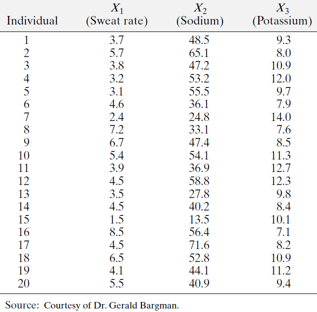

检验：

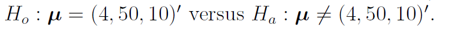

```r
z=read.table(file=paste(dirdata,"norm2.DAT",sep=""))
head(z)
```

```
##    V1   V2   V3
## 1 3.7 48.5  9.3
## 2 5.7 65.1  8.0
## 3 3.8 47.2 10.9
## 4 3.2 53.2 12.0
## 5 3.1 55.5  9.7
## 6 4.6 36.1  7.9
```

```r
dim(z)
```

```
## [1] 20  3
```

```r
colMeans(z)
```

```
##     V1     V2     V3
##  4.640 45.400  9.965
```

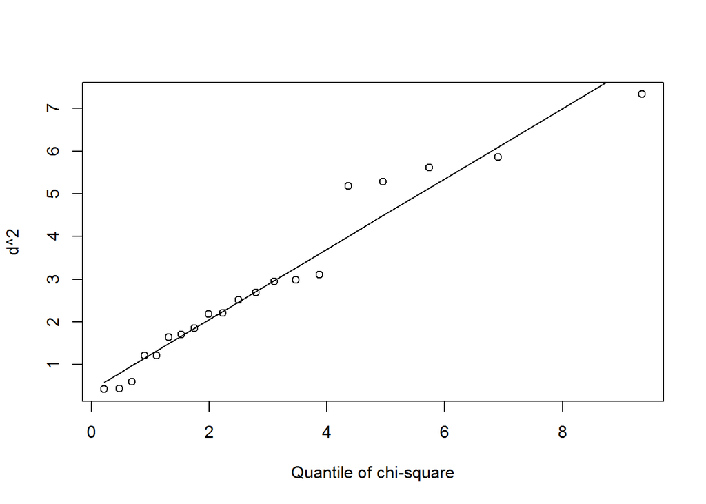

```
## correlation coefficient: 0.975713
```

```r
colnames(z) <- c("rate","Sodium","Potassium")
qqchi2(z)
```

```r
#source("Hotelling.R")
Hotelling(z,c(4,50,10))
```

```
##                     [,1]
## Hoteliing-T2  9.73877286
## p.value       0.06492834
## 1df           3.00000000
## 2df          17.00000000
```

```r
#HotellingsT2(z,c(4,50,10))
```

### 例3

```r
    x=read.table(file=paste(dirdata,"m-ba4c9807.txt",sep=""))
 #   source("confreg.R")
#    confreg(x)
```

### 配对样本检验实例

美国要求所有企业的的污水排除都必须安装自动检测装置，下面同一种检测装置分别放置在两个不同的实验室且对污水中两种检测指标的11条记录，请分析这两个实验室的这两种指标是否有所不同。

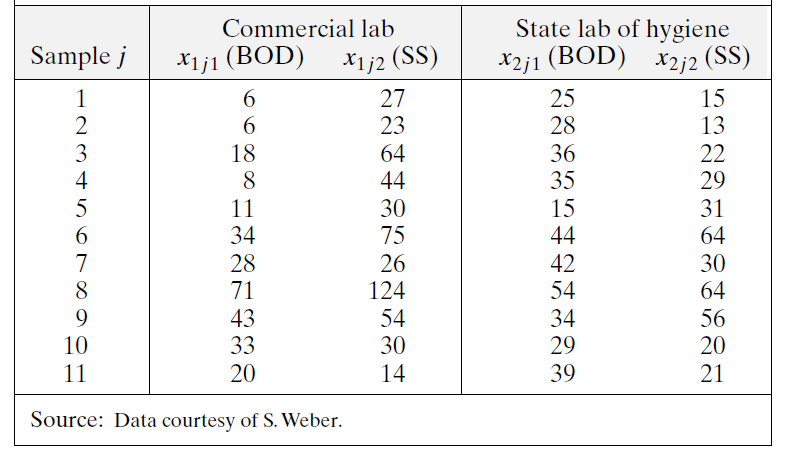

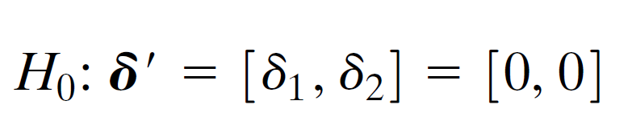

```r
x=read.table(file=paste(dirdata,"T6-1.DAT",sep=""))
d1=x[,1]-x[,3]
d2=x[,2]-x[,4]
d=cbind(d1,d2)
#source('Hotelling.R')
Hotelling(d,rep(0,2))
```

```
##                     [,1]
## Hoteliing-T2 13.63931214
## p.value       0.02082779
## 1df           2.00000000
## 2df           9.00000000
```

```r
#source("confreg.R")
#confreg(d)
```

## 两总体均值向量的比较

### 两总体均值向量是否相等的检验

例： 检验一下下面随机生成的两个样本的均值向量是否相同。

```r
library(mvtnorm)
X1<- rmvnorm(20, c(0, 0, 0, 0, 0))
X2<- rmvnorm(20, c(0,0, 4, 0, 0))
```

调用Hotellings检验

```r
library(ICSNP)
HotellingsT2(X1, X2)
```

```
##
##  Hotelling's two sample T2-test
##
## data:  X1 and X2
## T.2 = 30.98, df1 = 5, df2 = 34, p-value = 9.682e-12
## alternative hypothesis: true location difference is not equal to c(0,0,0,0,0)
```

例4：教材P48 3-4题。

```r
data3.3=read.csv("http://statstudy.github.io/data/data3_3.csv",head=T)#读入数据#
head(data3.3)
```

```
##   X1 X2 X3 X4
## 1  5  6  9  8
## 2  8  5  3  6
## 3  9  6  7  9
## 4  9  2  2  8
## 5  9  4  3  7
## 6  9  5  3  7
```

```r
HotellingsT2(data3.3, mu=c(7,5,4,8))#Hotellings检验#
```

```
##
##  Hotelling's one sample T2-test
##
## data:  data3.3
## T.2 = 7.5968, df1 = 4, df2 = 16, p-value = 0.00125
## alternative hypothesis: true location is not equal to c(7,5,4,8)
```

### 多个总体的均值向量的比较的检验

例：检验一下三个随机得到样本均值向量是否相同。

```r
X1<- rmvnorm(20, c(0, 0, 0, 0, 0), diag(5))
X2<- rmvnorm(20, c(0,0, 4, 0, 0), diag(5))
X3<- rmvnorm(20, c(0,0, 0, 0, 0.05), diag(5))
```

使用多元方差分析对多个总体均值向量做比较

```r
X=rbind(cbind(1,X1),cbind(2,X2),cbind(3,X3));head(X)
```

```
##      [,1]       [,2]        [,3]       [,4]        [,5]        [,6]
## [1,]    1 -0.7347112  0.58518320  0.9495570  0.02349733  1.18899521
## [2,]    1 -0.6133874  0.54126357 -0.2354327  0.59940469  1.51577889
## [3,]    1 -1.4620623 -0.08229373  1.5400677 -1.39282466 -0.02373865
## [4,]    1  1.4660343  0.46755956 -1.1543289 -1.38659024  2.09126575
## [5,]    1 -1.1362709 -0.88427877 -0.7875971  1.29323161  0.11880116
## [6,]    1 -1.3558850  0.48944687  0.9491266 -2.36546325  0.10233496
```

```r
xx=X[,2:6]
head(xx)
```

```
##            [,1]        [,2]       [,3]        [,4]        [,5]
## [1,] -0.7347112  0.58518320  0.9495570  0.02349733  1.18899521
## [2,] -0.6133874  0.54126357 -0.2354327  0.59940469  1.51577889
## [3,] -1.4620623 -0.08229373  1.5400677 -1.39282466 -0.02373865
## [4,]  1.4660343  0.46755956 -1.1543289 -1.38659024  2.09126575
## [5,] -1.1362709 -0.88427877 -0.7875971  1.29323161  0.11880116
## [6,] -1.3558850  0.48944687  0.9491266 -2.36546325  0.10233496
```

```r
fac=factor(X[,1]);fac
```

```
##  [1] 1 1 1 1 1 1 1 1 1 1 1 1 1 1 1 1 1 1 1 1 2 2 2 2 2 2 2 2 2 2 2 2 2 2 2
## [36] 2 2 2 2 2 3 3 3 3 3 3 3 3 3 3 3 3 3 3 3 3 3 3 3 3
## Levels: 1 2 3
```

```r
re=manova(xx~factor(X[,1]))
summary(re)
```

```
##                Df  Pillai approx F num Df den Df    Pr(>F)
## factor(X[, 1])  2 0.89246   8.7026     10    108 2.545e-10 ***
## Residuals      57
## ---
## Signif. codes:  0 '***' 0.001 '**' 0.01 '*' 0.05 '.' 0.1 ' ' 1
```

## 多元总体的协方差阵的检验

例： 检验一下上个例子中各个样本的协方差阵是否一致。

```r
library(biotools)
boxM(X[,2:6],factor(X[,1]))
```

```
##
##  Box's M-test for Homogeneity of Covariance Matrices
##
## data:  X[, 2:6]
## Chi-Sq (approx.) = 23.394, df = 30, p-value = 0.7987
```

返回[课程主页](https://statstudy.github.io/Rmulti.html)。